# GA_analysis

Michael Breshock

3/28/2024

remember to update

```r
theme_set(theme_linedraw() +
            theme(axis.text = element_text(size = 11,
                                           color = "black"),
                  axis.title = element_text(size = 12,
                                            color = "black"),
                  plot.title = element_text(size = 14,
                                            color = "black",
                                            hjust = .5))
          )
```

```r
ocs_property_id = 256923228
dates = ga_data(ocs_property_id,
        date_range = c("2021-01-01", "yesterday"),
        metrics = c("sessions"),
        dimensions = c("date"), limit = -1)
```

```
## ℹ 2024-03-28 10:43:04.035125 > Downloaded [ 1175 ] of total [ 1175 ] rows
```

```r
dates
```

```
## # A tibble: 1,175 × 2
##    date       sessions
##    <date>        <dbl>
##  1 2021-11-02      104
##  2 2023-03-29       99
##  3 2023-08-07       95
##  4 2023-01-26       87
##  5 2023-08-08       87
##  6 2023-08-03       84
##  7 2022-02-21       83
##  8 2023-02-20       77
##  9 2023-05-03       76
## 10 2023-08-10       76
## # ℹ 1,165 more rows
```

```r
ocs_property_id = 256923228
ses_wk_ctg = ga_data(ocs_property_id,
          date_range = c("2021-01-01", "yesterday"),
          metrics = c("sessions"),
          dimensions = c("deviceCategory"),
          limit = -1)
```

```
## ℹ 2024-03-28 10:43:04.993008 > Downloaded [ 3 ] of total [ 3 ] rows
```

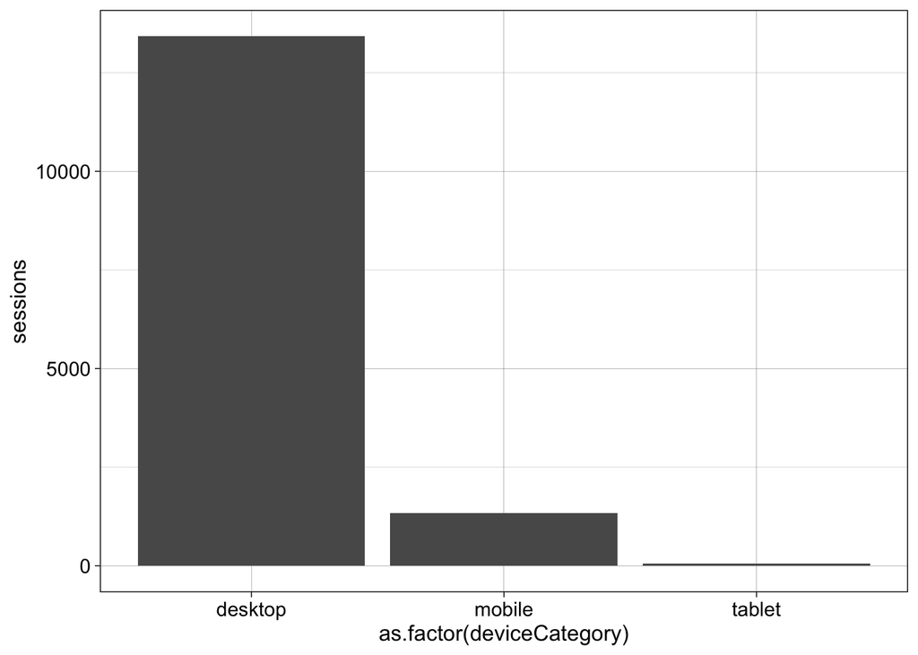

```r
ses_wk_ctg %<>% mutate(percent = round(100*sessions/sum(sessions), 2),
                       total = sum(sessions))

ggplot(ses_wk_ctg, aes(x = as.factor(deviceCategory), y = sessions)) +
  geom_bar(stat = "identity")
```

[Paramaters:](https://developers.google.com/analytics/devguides/reporting/data/v1/api-schema)

sessions: The number of sessions that began on your site or app (event triggered: session_start).

deviceCategory: The type of device: Desktop, Tablet, or Mobile.

```r
user_sources = ga_data(ocs_property_id,
          date_range = c("2021-01-01", "yesterday"),
          metrics = c("newUsers"),
          dimensions = c("firstUserSource"),
          limit = -1) %>%
  subset(grepl("127",firstUserSource) == FALSE) %>%
  mutate(firstUserSource = as_factor(firstUserSource),
         firstUserSource = fct_infreq(firstUserSource))
```

```
## ℹ 2024-03-28 10:43:08.308384 > tokensPerDay: Query Cost [ 71 ] / Remaining [ 197461 ]
```

```
## ℹ 2024-03-28 10:43:08.316669 > tokensPerHour: Query Cost [ 71 ] / Remaining [ 38661 ]
```

```
## ℹ 2024-03-28 10:43:08.328437 > concurrentRequests: Query Cost [ 0 ] / Remaining [ 10 ]
```

```
## ℹ 2024-03-28 10:43:08.336585 > serverErrorsPerProjectPerHour: Query Cost [ 0 ] / Remaining [ 10 ]
```

```
## ℹ 2024-03-28 10:43:08.351953 > Downloaded [ 81 ] of total [ 81 ] rows
```

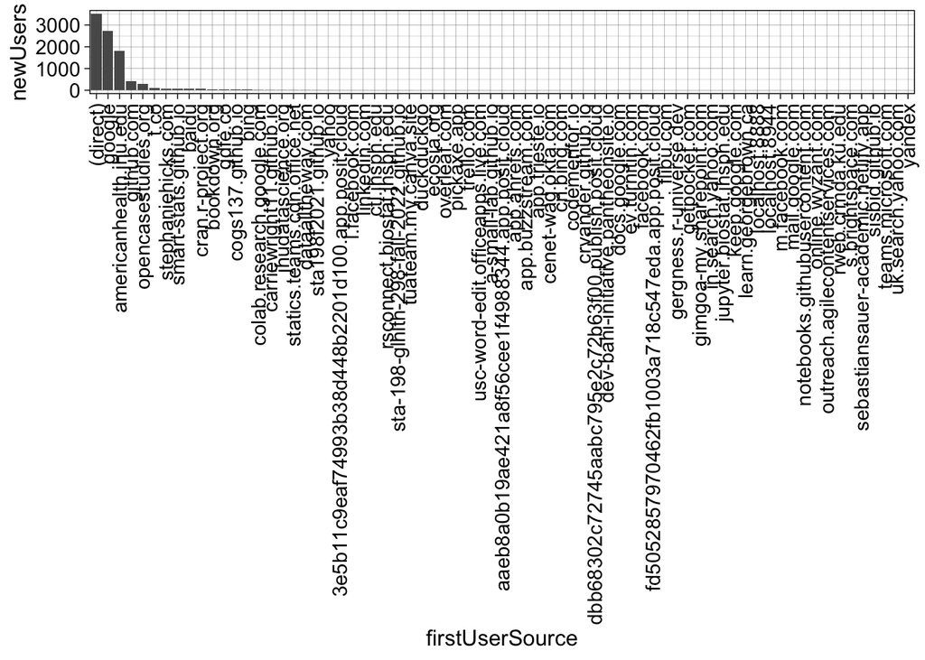

```r
ggplot(user_sources, aes(x = firstUserSource, y = newUsers)) +
  geom_bar(stat = "identity") +   theme(axis.text.x=element_text(angle=90,hjust=1,vjust=0.5))
```

(t.co = twitter)

firstUserSource = The source that first acquired the user to your website or app.

newUsers: The number of users who interacted with your site or launched your app for the first time (event triggered: first_open or first_visit).

```r
users_wk = ga_data(ocs_property_id,
          date_range = c("2021-01-01", "yesterday"),
          metrics = c("totalUsers", "newUsers", "eventCount",
                      "active7DayUsers", "userEngagementDuration"),
          dimensions = c("week"),
          limit = -1) %>%
  mutate(week = as.numeric(week),
         avgEngagementDuration = round(userEngagementDuration/(60*totalUsers)))
```

```
## ℹ 2024-03-28 10:43:08.894193 > Downloaded [ 53 ] of total [ 53 ] rows
```

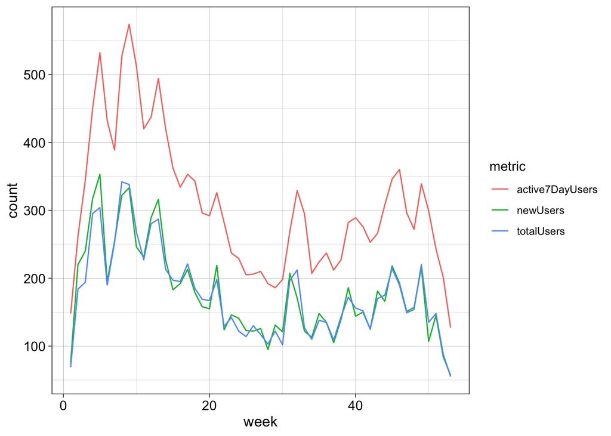

```r
pivot_longer(users_wk, c(totalUsers, newUsers, active7DayUsers),
             names_to = "metric", values_to = "count") %>%
  ggplot(aes(x = week, y = count)) +
  geom_line(aes(color = metric))
```

```r
ocs_property_id = 256923228
users_date = ga_data(ocs_property_id,
          date_range = c("2021-01-01", "yesterday"),
          metrics = c("totalUsers", "newUsers",
                      "active1DayUsers"),
          dimensions = c("date"), limit = -1) %>%
  pivot_longer(c(newUsers, active1DayUsers),
              names_to = "metric", values_to = "count")
```

```
## ℹ 2024-03-28 10:43:09.694034 > Downloaded [ 1175 ] of total [ 1175 ] rows
```

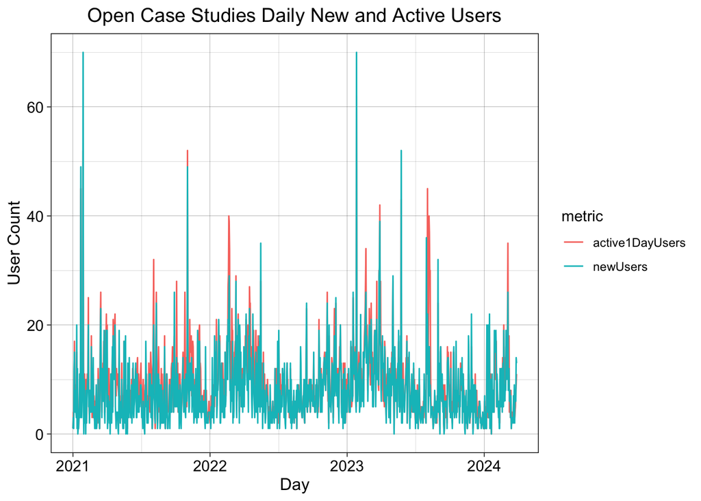

```r
  ggplot(users_date, aes(x = date, y = count, color = metric)) +
    geom_line() + #scale_color_viridis_d() +
    labs(x = "Day", y = "User Count", title = "Open Case Studies Daily New and Active Users")
```

```r
#users totals
ocs_property_id = 256923228
total_users = ga_data(ocs_property_id,
        date_range = c("2021-01-01", "yesterday"),
        metrics = c("totalUsers", "newUsers",
                 "active1DayUsers"),
        limit = -1)
```

```
## ℹ 2024-03-28 10:43:10.319648 > Downloaded [ 1 ] of total [ 1 ] rows
```

```r
avg_newusers = total_users$newUsers / nrow(dates)
avg_totusers = total_users$active1DayUsers / nrow(dates)
```

```r
ggplot(users_date, aes(x = as.factor(avgEngagementDuration),
                       fill = as.factor(avgEngagementDuration))) +
  geom_bar() + scale_fill_viridis_d() + guides(fill = "none") +
  labs(x = "Average Engagement Duration (Minutes)", y = "Number of Days",
       title = "Count of Daily Average Engagement")
```

[output not shown]

week: The week of the event, a two-digit number from 01 to 53. Each week starts on Sunday. January 1st is always in week 01. The first and last week of the year have fewer than 7 days in most years. Weeks other than the first and the last week of the year always have 7 days. For years where January 1st is a Sunday, the first week of that year and the last week of the prior year have 7 days.

totalUsers: The number of distinct users who have logged at least one event, regardless of whether the site or app was in use when that event was logged.

eventCount: The count of events.

active7DayUsers: The number of distinct active users on your site or app within a 7 day period. The 7 day period includes the last day in the report’s date range.

userEngagementDuration: The total amount of time (in seconds) your website or app was in the foreground of users’ devices.

```r
cities = ga_data(ocs_property_id,
          date_range = c("2021-01-01", "yesterday"),
          metrics = c("sessions"),
          dimensions = c("country", "city"), limit = -1)
```

```
## ℹ 2024-03-28 10:43:11.452699 > Downloaded [ 2360 ] of total [ 2360 ] rows
```

```r
cities %<>% mutate(
  latitude = geocode(paste(city, country, sep = ", "))$lat,
  longitude = geocode(paste(city, country, sep = ", "))$lon
)
cities
```

```
## # A tibble: 2,360 × 5
##    country       city         sessions latitude longitude
##    <chr>         <chr>           <dbl>    <dbl>     <dbl>
##  1 United States Baltimore        1440       NA        NA
##  2 United States Berkeley          514       NA        NA
##  3 United States San Diego         444       NA        NA
##  4 United States Seattle           330       NA        NA
##  5 Canada        Toronto           293       NA        NA
##  6 United States (not set)         290       NA        NA
##  7 United States Washington        280       NA        NA
##  8 United States Los Angeles       234       NA        NA
##  9 United States New York          220       NA        NA
## 10 United States Shippensburg      194       NA        NA
## # ℹ 2,350 more rows
```

city: The city from which the user activity originated.

```r
worldmap = map_data("world")
cities = drop_na(cities)
save(cities, file = "city_coordinates.rda")
```

```r
# Create a color palette with handmade bins.
mybins <- c(1, 5, 10, 50, 100, 1000, 2000)
mypalette <- colorBin(palette="Reds", domain = cities$sessions,
                      na.color="transparent", bins=mybins)
```

```r
# Final Map
m <- leaflet(cities) %>%
  addTiles()  %>%
  setView(lat = 0, lng = 0, zoom = 1) %>%
  addProviderTiles(providers$CartoDB.Positron) %>%
  addCircleMarkers(~longitude, ~latitude,
    fillColor = ~mypalette(sessions), fillOpacity = 0.7, radius= ~sqrt(sessions), stroke=FALSE
  ) %>%
  addLegend(pal=mypalette, values=~sessions, opacity=0.9, title = "Sessions", position = "topright" )

m
```

[interactive chart not shown]

[figure not shown]

```r
cities10 = drop_na(cities) %>% filter(country != "Peru") %>% head(10) %>%
  mutate(city = case_when(
    city == "(not set)" ~ " ",
    TRUE ~ city)) %>%
  unite(location, c(city, country), sep = "\n")

ggplot(cities10, aes(x = as_factor(location), y = sessions, fill = as_factor(location))) +
  geom_col() + scale_fill_viridis_d() +
  labs(x = "City, Country", y = "No. of Sessions",
       title = "Top Ten Cities With Most Open Case Studies Sessions") +
  guides(fill = "none") +
  theme(axis.text.x = element_text(angle = 60, vjust = 0.5)) +
  scale_y_continuous() +
  geom_text(aes(label = paste0(sessions)), vjust = -.5) + ylim(c(0,1150))
```

```r
ocs_property_id = 256923228
browsers = ga_data(ocs_property_id,
          date_range = c("2021-01-01", "yesterday"),
          metrics = c("sessions"),
          dimensions = c("browser"),
          limit = -1)
```

```
## ℹ 2024-03-28 10:48:16.774649 > Downloaded [ 18 ] of total [ 18 ] rows
```

```r
head(browsers)
```

```
## # A tibble: 6 × 2
##   browser          sessions
##   <chr>               <dbl>
## 1 Chrome              11008
## 2 Safari               2115
## 3 Edge                 1158
## 4 Firefox               521
## 5 Opera                 117
## 6 Samsung Internet       28
```

```r
ocs_property_id = 256923228
dhm = ga_data(ocs_property_id,
          date_range = c("2021-01-01", "yesterday"),
          metrics = c("sessions"),
          dimensions = c("hour"), limit = -1)
```

```
## ℹ 2024-03-28 10:48:16.986385 > Downloaded [ 24 ] of total [ 24 ] rows
```

```r
dhm
```

```
## # A tibble: 24 × 2
##    hour  sessions
##    <chr>    <dbl>
##  1 13        1075
##  2 14        1029
##  3 15         941
##  4 11         890
##  5 12         846
##  6 16         831
##  7 10         820
##  8 19         742
##  9 17         740
## 10 20         716
## # ℹ 14 more rows
```

```r
ocs_property_id = 256923228
mediums = ga_data(ocs_property_id,
          date_range = c("2021-01-01", "yesterday"),
          metrics = c("sessions"),
          dimensions = c("medium"),
          limit = -1)
```

```
## ℹ 2024-03-28 10:48:17.172142 > Downloaded [ 3 ] of total [ 3 ] rows
```

```r
mediums
```

```
## # A tibble: 3 × 2
##   medium   sessions
##   <chr>       <dbl>
## 1 referral     4464
## 2 (none)       4164
## 3 organic      3274
```

```r
ocs_property_id = 256923228
urls = ga_data(ocs_property_id,
          date_range = c("2021-01-01", "yesterday"),
          metrics = c("sessions"),
          dimensions = c("fullPageUrl"),
          limit = -1)
```

```
## ℹ 2024-03-28 10:48:17.392682 > Downloaded [ 59 ] of total [ 59 ] rows
```

```r
case_studies = c("ocs-bp-rural-and-urban-obesity",
                 "ocs-bp-air-pollution",
                 "ocs-bp-vaping-case-study",
                 "ocs-bp-opioid-rural-urban",
                 "ocs-bp-RTC-wrangling",
                 "ocs-bp-RTC-analysis",
                 "ocs-bp-youth-disconnection",
                 "ocs-bp-youth-mental-health",
                 "ocs-bp-school-shootings-dashboard",
                 "ocs-bp-co2-emissions",
                 "ocs-bp-diet")

pageUrl = urls %>% mutate(
  interactive = str_detect(fullPageUrl, "rsconnect")) %>%
  filter(str_detect(fullPageUrl, "opencasestudies.org") |
           str_detect(fullPageUrl, "jhsph.edu/ocs")) %>%
  mutate(
    code = case_when(
      str_detect(fullPageUrl, "ocs-bp-school-shootings-dashboard") == TRUE ~ "School Shootings",
      str_detect(fullPageUrl, "ocs-bp-youth-disconnection") == TRUE ~ "Youth Disconnection",
      str_detect(fullPageUrl, "ocs-bp-opioid-rural-urban") == TRUE ~ "Opiods",
      str_detect(fullPageUrl, "ocs-bp-vaping-case-study") == TRUE ~ "Vaping",
      str_detect(fullPageUrl, "ocs-bp-youth-mental-health") == TRUE ~ "Mental Health",
      str_detect(fullPageUrl, "ocs-bp-rural-and-urban-obesity") == TRUE ~ "Obesity",
      str_detect(fullPageUrl, "ocs-bp-RTC-analysis") == TRUE ~ "RTC Analysis",
      str_detect(fullPageUrl, "ocs-bp-co2-emissions") == TRUE ~ "CO2 Emissions",
      str_detect(fullPageUrl, "ocs-bp-RTC-wrangling") == TRUE ~ "RTC Wrangling",
      str_detect(fullPageUrl, "ocs-bp-diet") == TRUE ~ "Diet",
      str_detect(fullPageUrl, "ocs-bp-air-pollution") == TRUE ~ "Air Pollution"
    )
  )

pageTotals = pageUrl %>% group_by(code) %>%
  mutate(ocs_sum = sum(sessions)) %>% select(code, ocs_sum) %>% distinct()

interactiveTotals = pageUrl %>% filter(interactive == TRUE) %>% group_by(code) %>%
  mutate(ocs_sum = sum(sessions)) %>% select(code, ocs_sum, interactive) %>% distinct()

staticTotals = pageUrl %>% filter(interactive == FALSE) %>% group_by(code) %>%
  mutate(ocs_sum = sum(sessions)) %>% select(code, ocs_sum, interactive) %>% distinct()

cstotalsplot = ggplot(drop_na(pageTotals), aes(x = reorder(code, -ocs_sum), y = ocs_sum, fill = code)) +
  geom_bar(position = "dodge", stat = "identity") + scale_fill_viridis_d() +
  labs(x = "Case Study", y = "Session Count",
       title = "Number of Total Sessions by Case Study") +
  theme(axis.text.x = element_text(angle = 60, vjust = 0.5)) +
  guides(fill = "none") + geom_text(aes(label = paste0(ocs_sum)), vjust = -.5)
```

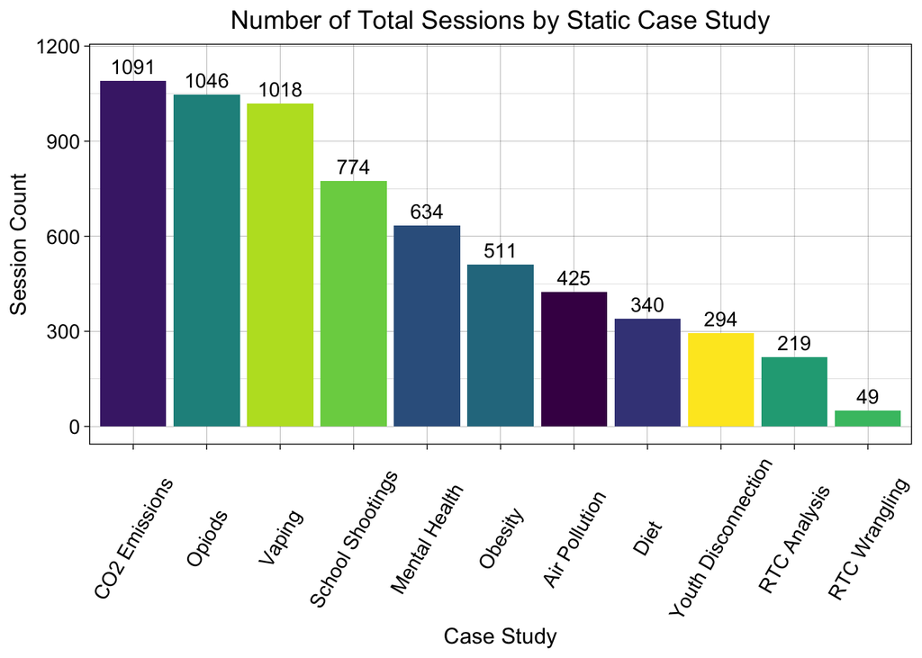

```r
staticplot = ggplot(drop_na(staticTotals),
                          aes(x = reorder(code, -ocs_sum), y = ocs_sum, fill = code)) +
  geom_bar(position = "dodge", stat = "identity") + scale_fill_viridis_d() +
  labs(x = "Case Study", y = "Session Count",
       title = "Number of Total Sessions by Static Case Study") +
  theme(axis.text.x = element_text(angle = 60, vjust = 0.5)) +
  guides(fill = "none") + geom_text(aes(label = paste0(ocs_sum)), vjust = -.5) +
  ylim(0,1150)
staticplot
```

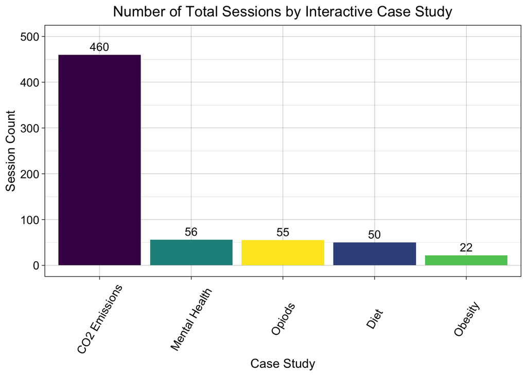

```r
interactivesplot = ggplot(drop_na(interactiveTotals),
                          aes(x = reorder(code, -ocs_sum), y = ocs_sum, fill = code)) +
  geom_bar(position = "dodge", stat = "identity") + scale_fill_viridis_d() +
  labs(x = "Case Study", y = "Session Count",
       title = "Number of Total Sessions by Interactive Case Study") +
  theme(axis.text.x = element_text(angle = 60, vjust = 0.5)) +
  guides(fill = "none") + geom_text(aes(label = paste0(ocs_sum)), vjust = -.5) +
  ylim(0,500)
interactivesplot
```

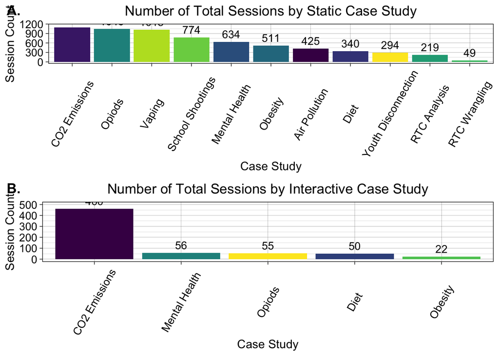

```r
ggarrange(staticplot, interactivesplot,
          labels = c("A.", "B."),
          ncol = 1, nrow = 2)
```

```r
ocs_property_id = 256923228
language = ga_data(ocs_property_id,
          date_range = c("2021-01-01", "yesterday"),
          metrics = c("newUsers"),
          dimensions = c("language"),
          limit = -1)
```

```
## ℹ 2024-03-28 10:48:19.692442 > Downloaded [ 42 ] of total [ 42 ] rows
```

```r
language
```

```
## # A tibble: 42 × 2
##    language   newUsers
##    <chr>         <dbl>
##  1 English        8312
##  2 Chinese         369
##  3 Spanish         217
##  4 French          105
##  5 German           73
##  6 Portuguese       65
##  7 Italian          63
##  8 Korean           46
##  9 Turkish          27
## 10 Arabic           25
## # ℹ 32 more rows
```

```r
ocs_property_id = 256923228
linkUrl = ga_data(ocs_property_id,
          date_range = c("2021-01-01", "yesterday"),
          metrics = c("sessions"),
          dimensions = c("linkUrl"),
          limit = -1)
```

```
## ℹ 2024-03-28 10:48:21.161305 > Downloaded [ 431 ] of total [ 431 ] rows
```

```r
linkUrl
```

```
## # A tibble: 431 × 2
##    linkUrl                                                              sessions
##    <chr>                                                                   <dbl>
##  1 ""                                                                      14858
##  2 "https://rsconnect.biostat.jhsph.edu/ocs-bp-school-shootings-dashbo…      113
##  3 "https://www.gapminder.org/data/"                                          90
##  4 "https://github.com/opencasestudies/ocs-bp-opioid-rural-urban/"            45
##  5 "https://cdiac.ess-dive.lbl.gov/"                                          44
##  6 "https://github.com//opencasestudies/ocs-bp-co2-emissions"                 33
##  7 "https://www.epa.gov/ghgemissions/inventory-us-greenhouse-gas-emiss…       30
##  8 "https://www.ncdc.noaa.gov/cag/national/time-series"                       30
##  9 "https://github.com/opencasestudies/ocs-bp-rural-and-urban-obesity"        29
## 10 "https://github.com/opencasestudies/ocs-bp-school-shootings-dashboa…       29
## # ℹ 421 more rows
```

```r
ocs_property_id = 256923228
OSversion = ga_data(ocs_property_id,
          date_range = c("2021-01-01", "yesterday"),
          metrics = c("sessions"),
          dimensions = c("operatingSystem"),
          limit = -1)
```

```
## ℹ 2024-03-28 10:48:21.447528 > Downloaded [ 7 ] of total [ 7 ] rows
```

```r
OSversion
```

```
## # A tibble: 7 × 2
##   operatingSystem sessions
##   <chr>              <dbl>
## 1 Windows             7360
## 2 Macintosh           5850
## 3 iOS                  751
## 4 Android              632
## 5 Chrome OS            186
## 6 Linux                 99
## 7 (not set)              3
```

```r
ocs_property_id = 256923228
pageReferrer = ga_data(ocs_property_id,
          date_range = c("2021-01-01", "yesterday"),
          metrics = c("sessions"),
          dimensions = c("pageReferrer"),
          limit = -1)
```

```
## ℹ 2024-03-28 10:48:22.811919 > Downloaded [ 373 ] of total [ 373 ] rows
```

```r
pageReferrer
```

```
## # A tibble: 373 × 2
##    pageReferrer                                                         sessions
##    <chr>                                                                   <dbl>
##  1 ""                                                                       3912
##  2 "https://www.google.com/"                                                3141
##  3 "https://americanhealth.jhu.edu/"                                        2527
##  4 "https://www.opencasestudies.org/OCS_search/"                            2362
##  5 "https://github.com/"                                                     601
##  6 "https://www.opencasestudies.org/"                                        417
##  7 "https://rsconnect.biostat.jhsph.edu/ocs-bp-co2-emissions-interacti…      244
##  8 "https://smart-stats.github.io/"                                          200
##  9 "https://www.stephaniehicks.com/"                                         106
## 10 "https://cran.r-project.org/"                                              99
## # ℹ 363 more rows
```

look into collapsing duplicates functions / group_by!

```r
ocs_property_id = 256923228
# used fullPageUrl instead
# pagetitle = ga_data(ocs_property_id,
#           date_range = c("2021-01-01", "yesterday"),
#           metrics = c("sessions"),
#           dimensions = c("pageTitle"))
# case_studies = c("School Shootings in the United States",
#                  "Disparities in Youth Disconnection",
#                  "Opioids in United States",
#                  "Vaping Behaviors in American Youth",
#                  "Mental Health of American Youth",
#                  "Exploring global patterns of obesity across rural and urban regions",  "Influence of Multicollinearity on Measured Impact of Right-to-Carry Gun Laws",
#                  "Exploring CO2 emissions across time",
#                  "Influence of Multicollinearity on Measured Impact of Right-to-Carry Gun Laws Part 1",
#                  "Exploring global patterns of dietary behaviors associated with health risk",
#                  "Predicting Annual Air Pollution")
# pages = pagetitle %>% mutate(
#   ocs = str_remove(pageTitle, pattern = "Open Case Studies: ")
# ) %>%
#   filter(ocs %in% case_studies) %>%
#   mutate(
#     static = str_count(pageTitle, "Open Case Studies: ")) %>%
#   mutate(
#     code = case_when(
#       ocs == "School Shootings in the United States" ~ "School Shootings",
#       ocs == "Disparities in Youth Disconnection" ~ "Youth Disconnection",
#       ocs == "Opioids in United States" ~ "Opiods",
#       ocs == "Vaping Behaviors in American Youth" ~ "Vaping",
#       ocs == "Mental Health of American Youth" ~ "Mental Health",
#       ocs == "Exploring global patterns of obesity across rural and urban regions" ~ "Obesity",
#       ocs == "Influence of Multicollinearity on Measured Impact of Right-to-Carry Gun Laws" ~ "RTC Analysis",
#       ocs == "Exploring CO2 emissions across time" ~ "CO2 Emissions",
#       ocs == "Influence of Multicollinearity on Measured Impact of Right-to-Carry Gun Laws Part 1" ~ "RTC Wrangling",
#       ocs == "Exploring global patterns of dietary behaviors associated with health risk" ~ "Diet",
#       ocs == "Predicting Annual Air Pollution" ~ "Air Pollution"
#     )
#   ) %>% group_by(code) %>%
#   mutate(ocs_sum = sum(sessions)) %>% select(code, ocs_sum) %>% distinct()
# pages
```

```r
ocs_property_id = 256923228
percentScrolled = ga_data(ocs_property_id,
          date_range = c("2021-01-01", "yesterday"),
          metrics = c("sessions"),
          dimensions = c("percentScrolled"),
          limit = -1)
```

```
## ℹ 2024-03-28 10:48:23.096573 > Downloaded [ 3 ] of total [ 3 ] rows
```

```r
percentScrolled
```

```
## # A tibble: 3 × 2
##   percentScrolled sessions
##   <chr>              <dbl>
## 1 ""                 14859
## 2 "90"                3982
## 3 ""                     0
```

```r
ocs_property_id = 256923228
searchTerm = ga_data(ocs_property_id,
          date_range = c("2021-01-01", "yesterday"),
          metrics = c("sessions"),
          dimensions = c("searchTerm"),
          limit = -1)
```

```
## ℹ 2024-03-28 10:48:23.310326 > Downloaded [ 2 ] of total [ 2 ] rows
```

```r
searchTerm
```

```
## # A tibble: 2 × 2
##   searchTerm sessions
##   <chr>         <dbl>
## 1 ""            14879
## 2 ""                0
```

```r
ocs_property_id = 256923228
sources = ga_data(ocs_property_id,
          date_range = c("2021-01-01", "yesterday"),
          metrics = c("sessions"),
          dimensions = c("source"),
          limit = -1)
```

```
## ℹ 2024-03-28 10:48:26.720624 > tokensPerDay: Query Cost [ 110 ] / Remaining [ 197253 ]
```

```
## ℹ 2024-03-28 10:48:26.730592 > tokensPerHour: Query Cost [ 110 ] / Remaining [ 38453 ]
```

```
## ℹ 2024-03-28 10:48:26.74906 > concurrentRequests: Query Cost [ 0 ] / Remaining [ 10 ]
```

```
## ℹ 2024-03-28 10:48:26.759494 > serverErrorsPerProjectPerHour: Query Cost [ 0 ] / Remaining [ 10 ]
```

```
## ℹ 2024-03-28 10:48:26.77909 > Downloaded [ 83 ] of total [ 83 ] rows
```

```r
sources
```

```
## # A tibble: 83 × 2
##    source                    sessions
##    <chr>                        <dbl>
##  1 (direct)                      4164
##  2 google                        3158
##  3 americanhealth.jhu.edu        2172
##  4 github.com                    1101
##  5 opencasestudies.org            333
##  6 smart-stats.github.io          305
##  7 cran.r-project.org             104
##  8 stephaniehicks.com              96
##  9 cogs137.github.io               82
## 10 colab.research.google.com       74
## # ℹ 73 more rows
```

```r
ocs_property_id = 256923228
engagedSessions = ga_data(ocs_property_id,
          date_range = c("2021-01-01", "yesterday"),
          metrics = c("engagedSessions", "engagementRate", "sessions"),
          dimensions = c("week"), limit = -1)
```

```
## ℹ 2024-03-28 10:48:27.683897 > Downloaded [ 53 ] of total [ 53 ] rows
```

```r
ses_long = engagedSessions %>%
  pivot_longer(c(sessions, engagedSessions), names_to = "metric", values_to = "count")

sesplot = ggplot(ses_long, aes(x = as.numeric(week), y = count, color = metric)) +
  geom_line() +
  labs(x = "Week Number", y = "Count", title = "Open Case Studies Weekly Sessions and Engaged Sessions")
```

```r
engageplot = ggplot(engagedSessions, aes(x = as.numeric(week), y = engagementRate,
                            color = engagementRate)) +
  geom_line() +
  labs(x = "Week Number", y = "Engagement Rate",
       title = "Open Case Studies Weekly Engagement Rate") + guides(color = "none")
  #scale_color_manual(labels = "engagmentRate", values = "#8C4799")
```

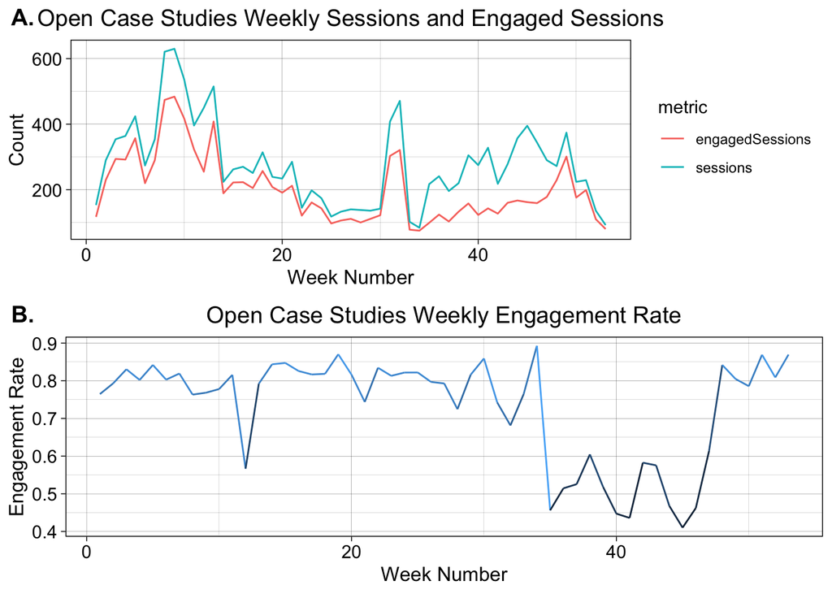

```r
ggarrange(sesplot, engageplot,
          labels = c("A.", "B."),
          ncol = 1, nrow = 2)
```

```r
#totals
totalSessions = ga_data(ocs_property_id,
          date_range = c("2021-01-01", "today"),
          metrics = c("engagedSessions", "engagementRate", "sessions"),
          limit = -1)
```

```
## ℹ 2024-03-28 10:48:40.000015 > Downloaded [ 1 ] of total [ 1 ] rows
```

```r
avgsessions = totalSessions$sessions / nrow(dates)
avgengagedsessions = totalSessions$engagedSessions / nrow(dates)
```

```r
ocs_property_id = 256923228
screenPageViews = ga_data(ocs_property_id,
          date_range = c("2021-01-01", "yesterday"),
          metrics = c("screenPageViews"),
          dimensions = c("pageTitle"), limit = -1)
```

```
## ℹ 2024-03-28 10:48:41.649642 > Downloaded [ 88 ] of total [ 88 ] rows
```

```r
screenPageViews
```

```
## # A tibble: 88 × 2
##    pageTitle                                                     screenPageViews
##    <chr>                                                                   <dbl>
##  1 Open Case Studies: Vaping Behaviors in American Youth                    2221
##  2 Open Case Studies: Opioids in United States                              2198
##  3 Exploring CO2 emissions across time                                      1733
##  4 Open Case Studies: Exploring CO2 emissions across time                   1706
##  5 Open Case Studies: Predicting Annual Air Pollution                       1576
##  6 Open Case Studies: School Shootings in the United States                 1552
##  7 Open Case Studies: Exploring global patterns of obesity acro…            1461
##  8 Open Case Studies: Mental Health of American Youth                       1285
##  9 Open Case Studies: Exploring global patterns of dietary beha…             890
## 10 Open Case Studies: Disparities in Youth Disconnection                     859
## # ℹ 78 more rows
```

```r
ocs_property_id = 256923228
sessionsPerUser = ga_data(ocs_property_id,
          date_range = c("2021-01-01", "yesterday"),
          metrics = c("sessionsPerUser"),
          dimensions = c("pageTitle"), limit = -1)
```

```
## ℹ 2024-03-28 10:48:43.031443 > Downloaded [ 88 ] of total [ 88 ] rows
```

```r
sessionsPerUser
```

```
## # A tibble: 88 × 2
##    pageTitle                                                     sessionsPerUser
##    <chr>                                                                   <dbl>
##  1 Étude de cas : Exploration des émissions de CO2 au fil du te…            8.71
##  2 Estudos de caso abertos: previsão da poluição atmosférica an…            6
##  3 公開案例研究：跨時間探索二氧化碳排放量                                   6
##  4 Explorer les émissions de CO2 au fil du temps                            3
##  5 Open Case Studies: Vaping Behaviors in American Youth --- 开…            3
##  6 开放案例研究：探索随时间变化的二氧化碳排放量                             3
##  7 Open Case Studies: Exploring CO2 emissions across time                   2.17
##  8 Open Case Studies: Opioids in United States                              2.04
##  9 Açık Vaka Çalışmaları: Amerika Birleşik Devletleri'ndeki Opi…            2
## 10 Estudios de caso abiertos: exploración de patrones globales …            2
## # ℹ 78 more rows
```

```r
ocs_property_id = 256923228
conversions = ga_data(ocs_property_id,
          date_range = c("2021-01-01", "yesterday"),
          metrics = c("conversions"),
          dimensions = c("eventName"), limit = -1)
```

```
## ℹ 2024-03-28 10:48:43.216764 > Downloaded [ 7 ] of total [ 7 ] rows
```

```r
conversions
```

```
## # A tibble: 7 × 2
##   eventName       conversions
##   <chr>                 <dbl>
## 1 page_view             16493
## 2 click                     0
## 3 file_download             0
## 4 first_visit               0
## 5 scroll                    0
## 6 session_start             0
## 7 user_engagement           0
```

dimensions of interest: - browser - cohort - country/countryID - dateHourMinute - firstSessionDate - fileName - firstUserMedium - firstUserTrafficOrigin - fullPageUrl - hour, minute - language, languageCode - linkClasses, linkDomain, linkUrl - medium, method - operatingSystem, operatingSystemWithVersion - pageLocation, pageReferrer - pageTitle - percentScrolled - searchTerm - streamName - sessionSource, source, sessionMedium

metrics of interest: - active1DayUsers - conversions - engagedSessions, engagementRate - screenPageViews - sessions, sessionsPerUser

for users data: use active1Dayusers and newUsers

cool figure to make: # of events (or users) per day (events y axis, days x axis) have a timeline of project development along the x-axis to view if website traffic was changed at all by project developments.

helpful links: https://www.dase-analytics.com/blog/en/how-to-get-data-from-google-analytics-using-r-programming/

https://ga-dev-tools.web.app/dimensions-metrics-explorer/

https://developers.google.com/analytics/devguides/reporting/data/v1/api-schema